# Congress Report

Tejveer Rai

This report is a display of data concerning the United States congress, including actions and voting records. The following data was processed from the information collected by the Sunlight Foundation. Specifically, we’ll be working with the **98105** zip code!

## Local Representatives

The local representatives for this district are:

[figure not shown]

- Pramila Jayapal ( WA - D ) Phone: 202-225-3106

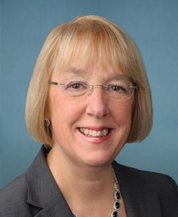

- Patty Murray ( WA - D ) Phone: 202-224-2621

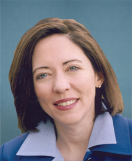

- Maria Cantwell ( WA - D ) Phone: 202-224-3441

## Congressional Bills

The table below lists 25 bills that are related to the topic of *health care*. There is some general information included in the table but feel free to click the link to get an in-depth look at any of the bills!

| Bill ID | Introduction Date | Official Title | Link to Bill |
| --- | --- | --- | --- |
| hr394-115 | 2017-01-10 | To amend the Internal Revenue Code of 1986 to repeal the amendments made by the Patient Protection and Affordable Care Act which disqualify expenses for over-the-counter drugs under health savings acc… | [Link](https://www.congress.gov/bill/115th/house-bill/394) |
| s85-115 | 2017-01-10 | A bill to amend the Internal Revenue Code of 1986 to repeal the amendments made by the Patient Protection and Affordable Care Act which disqualify expenses for over-the-counter drugs under health savi… | [Link](https://www.congress.gov/bill/115th/senate-bill/85) |
| hr370-115 | 2017-01-09 | To repeal the Patient Protection and Affordable Care Act and health care-related provisions in the Health Care and Education Reconciliation Act of 2010, and for other purposes. | [Link](https://www.congress.gov/bill/115th/house-bill/370) |
| hres32-115 | 2017-01-06 | Recognizing July 28, 2017, as “World Hepatitis Day”. | [Link](https://www.congress.gov/bill/115th/house-resolution/32) |
| hjres21-115 | 2017-01-06 | Proposing an amendment to the Constitution of the United States to limit Congress’ power to impose a tax on a failure to purchase goods or services. | [Link](https://www.congress.gov/bill/115th/house-joint-resolution/21) |
| hr314-115 | 2017-01-05 | To repeal title I of the Patient Protection and Affordable Care Act and to amend the Public Health Service Act to provide for cooperative governing of individual health insurance coverage offered in i… | [Link](https://www.congress.gov/bill/115th/house-bill/314) |
| hr302-115 | 2017-01-05 | To provide protections for certain sports medicine professionals who provide certain medical services in a secondary State. | [Link](https://www.congress.gov/bill/115th/house-bill/302) |
| hr307-115 | 2017-01-05 | To ensure that Members of Congress and Congressional staff receive health care from the Department of Veterans Affairs instead of under the Federal Health Benefits Program or health care exchanges. | [Link](https://www.congress.gov/bill/115th/house-bill/307) |
| hres26-115 | 2017-01-05 | Expressing the sense of the House of Representatives that the provisions of the Patient Protection and Affordable Care Act that restored the original black lung benefits eligibility requirements shoul… | [Link](https://www.congress.gov/bill/115th/house-resolution/26) |
| hr315-115 | 2017-01-05 | To amend the Public Health Service Act to distribute maternity care health professionals to health professional shortage areas identified as in need of maternity care health services. | [Link](https://www.congress.gov/bill/115th/house-bill/315) |
| hr309-115 | 2017-01-05 | To amend the Public Health Service Act to foster more effective implementation and coordination of clinical care for people with a complex metabolic or autoimmune disease, a disease resulting from ins… | [Link](https://www.congress.gov/bill/115th/house-bill/309) |
| hr304-115 | 2017-01-05 | To amend the Controlled Substances Act with regard to the provision of emergency medical services. | [Link](https://www.congress.gov/bill/115th/house-bill/304) |
| hr287-115 | 2017-01-04 | To amend the Internal Revenue Code of 1986 to exempt student workers for purposes of determining a higher education institution’s employer health care shared responsibility. | [Link](https://www.congress.gov/bill/115th/house-bill/287) |
| hr277-115 | 2017-01-04 | To repeal the Patient Protection and Affordable Care Act and related reconciliation provisions, to promote patient-centered health care, to provide for the creation of a safe harbor for defendants in … | [Link](https://www.congress.gov/bill/115th/house-bill/277) |
| hr246-115 | 2017-01-04 | To repeal the annual fee on health insurance providers enacted by the Patient Protection and Affordable Care Act. | [Link](https://www.congress.gov/bill/115th/house-bill/246) |
| hr47-115 | 2017-01-03 | To amend the Omnibus Crime Control and Safe Streets Act of 1968 to provide for the humane treatment of youths who are in police custody, and for other purposes. | [Link](https://www.congress.gov/bill/115th/house-bill/47) |
| hr42-115 | 2017-01-03 | To authorize the Directors of Veterans Integrated Service Networks of the Department of Veterans Affairs to enter into contracts with appropriate civilian accreditation entities or appropriate health … | [Link](https://www.congress.gov/bill/115th/house-bill/42) |
| hr161-115 | 2017-01-03 | To amend the Public Health Service Act to establish a grant program to provide supportive services in permanent supportive housing for chronically homeless individuals and families, and for other purp… | [Link](https://www.congress.gov/bill/115th/house-bill/161) |
| hr147-115 | 2017-01-03 | To prohibit discrimination against the unborn on the basis of sex or race, and for other purposes. | [Link](https://www.congress.gov/bill/115th/house-bill/147) |
| hr173-115 | 2017-01-03 | To amend the Internal Revenue Code of 1986 to repeal the excise tax on high cost employer-sponsored health coverage. | [Link](https://www.congress.gov/bill/115th/house-bill/173) |
| hr28-115 | 2017-01-03 | To amend title 38, United States Code, to direct the Secretary of Veterans Affairs to adopt and implement a standard identification protocol for use in the tracking and procurement of biological impla… | [Link](https://www.congress.gov/bill/115th/house-bill/28) |
| s12-115 | 2017-01-03 | A bill to amend title 38, United States Code, to improve the accountability of employees of the Department of Veterans Affairs, and for other purposes. | [Link](https://www.congress.gov/bill/115th/senate-bill/12) |
| hr59-115 | 2017-01-03 | To enhance the security of chemical facilities, and for other purposes. | [Link](https://www.congress.gov/bill/115th/house-bill/59) |
| hr159-115 | 2017-01-03 | To expand the workforce of veterinarians specialized in the care and conservation of wild animals and their ecosystems, and to develop educational programs focused on wildlife and zoological veterinar… | [Link](https://www.congress.gov/bill/115th/house-bill/159) |
| hr35-115 | 2017-01-03 | To amend the Internal Revenue Code of 1986 to modify rules relating to health savings accounts. | [Link](https://www.congress.gov/bill/115th/house-bill/35) |

# Voting on an Issue

### Individual Votes

The following vote data is in regards to the nomination of Rex W. Tillerson, former chairman and chief of Exxon Mobil, as secretary of state. His nomination set out to make history as he now holds the record for the most opposing votes in Senate history! See how the vote for his nomation breaks down per individual:

| Vote | First Name | Last Name | Political Party |
| --- | --- | --- | --- |
| Nay | Maria | Cantwell | D |
| Nay | Patty | Murray | D |

### Party Votes

This table is a grouping of the data by political party. Here we can see how each party favored the nomination and what the majority decision ended up being.

| Political Party | Majority Vote | Majority Vote Count | Party Members Count |
| --- | --- | --- | --- |
| D | Nay | 42 | 45 |
| I | Nay | 1 | 2 |
| R | Yea | 52 | 52 |

Here we can observe how our data compares by seeing whether the local representatives agreed or disagreed with the majority vote for their party on this specific issue!

| First Name | Last Name | Agreed/Disagreed With Party Majority Vote |
| --- | --- | --- |
| Maria | Cantwell | With |
| Patty | Murray | With |

### Visual

Looking at the bar graph below, we can see a visual representation of the breakdown of votes on this proposal. We can observe the number of each vote as well as how many party members made up the overall vote.

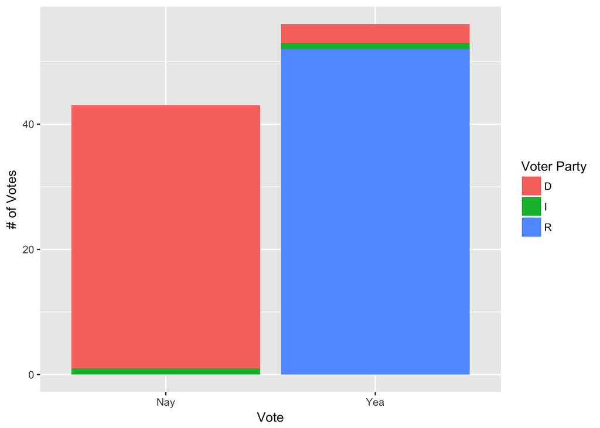